# HW5

Xiaotian Ding

2019/2/22

## HW5

8.16

beta0: the part of intercept of the function

beta2: If x2=0, the intercept is beta0. If the x2=1, the intercept will be beta0+beta2.

beta1: The slope of the function. If the x1 increase one unit, the y will increase beta1 unit.

Epsilon.i: Random error term and follow the N distribution in linear regression assumption.

```r
setwd("~/Desktop/Study in NU/Winter/Regression analysis/Regression analysis/Archive/Chapter  8 Data Sets")
data.x2<-read.table("CH08PR16.txt")
colnames(data.x2)<- c("major decide or not")
setwd("~/Desktop/Study in NU/Winter/Regression analysis/Regression analysis/Archive/Chapter  1 Data Sets")
data.y.x1<- read.table("CH01PR19.txt")
colnames(data.y.x1)<- c("GPA","Entrance score")
data<- cbind(data.y.x1,data.x2)
y<- data$GPA
x1<-data$`Entrance score`
x2<-data$`major decide or not`
cor(data[ ,c(1,2,3)])
```

```
##                             GPA Entrance score major decide or not
## GPA                  1.00000000     0.26948180         -0.09440012
## Entrance score       0.26948180     1.00000000         -0.09239064
## major decide or not -0.09440012    -0.09239064          1.00000000
```

```r
fit<- lm(y~x1+x2)
summary(fit)
```

```
##
## Call:
## lm(formula = y ~ x1 + x2)
##
## Residuals:
##      Min       1Q   Median       3Q      Max
## -2.70304 -0.35574  0.02541  0.45747  1.25037
##
## Coefficients:
##             Estimate Std. Error t value Pr(>|t|)
## (Intercept)  2.19842    0.33886   6.488 2.18e-09 ***
## x1           0.03789    0.01285   2.949  0.00385 **
## x2          -0.09430    0.11997  -0.786  0.43341
## ---
## Signif. codes:  0 '***' 0.001 '**' 0.01 '*' 0.05 '.' 0.1 ' ' 1
##
## Residual standard error: 0.6241 on 117 degrees of freedom
## Multiple R-squared:  0.07749,    Adjusted R-squared:  0.06172
## F-statistic: 4.914 on 2 and 117 DF,  p-value: 0.008928
```

E{y}=2.19842-0.09430x2+0.03789x1

```r
#F test
dropx2<- lm(y~x1)
anova(dropx2,fit)
```

```
## Analysis of Variance Table
##
## Model 1: y ~ x1
## Model 2: y ~ x1 + x2
##   Res.Df    RSS Df Sum of Sq      F Pr(>F)
## 1    118 45.818
## 2    117 45.577  1   0.24071 0.6179 0.4334
```

```r
n=dim(data)[1]
p=3
g=1
a=0.01
qf(1-a,p-1-g,n-p)
```

```
## [1] 6.856564
```

H0:

reduce model: E{y}=beta0+beta1*x1

Ha:

full model: E{y}=beta0+beta2*x2+beta1*x1

RR: F>F(1-a,p-1-g,n-p)

F=0.6179<F(1-a,p-1-g,n-p)=6.856564

Thus, we conclude H0 and x2 can be dropped.

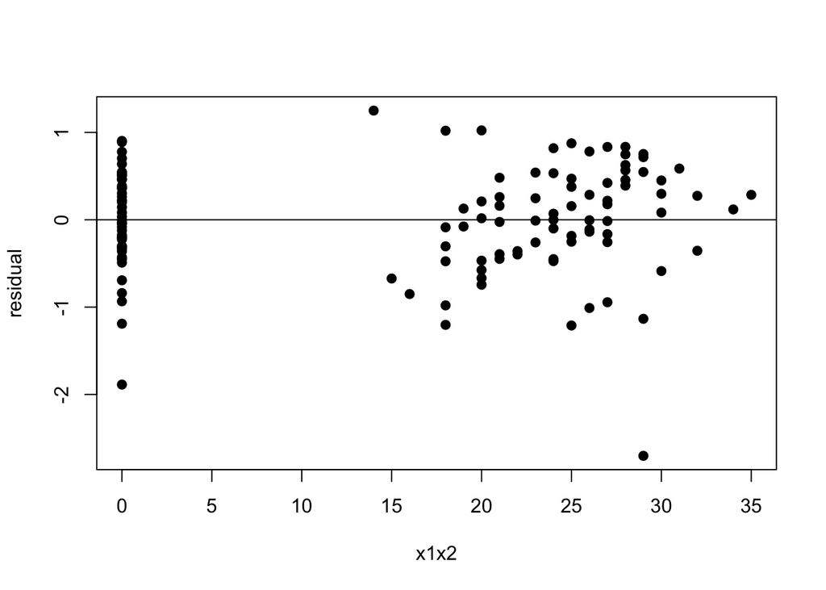

```r
residual.y.x1.x2<-fit$residuals
x1x2<-x1*x2
plot(x1x2,residual.y.x1.x2,xlab = "x1x2",ylab = "residual", pch=19)
abline(h=0)
```

With the increase of x1x2, the residual has a trend to increase not scattering randomly around zero. Thus, there is interaction term in model.

8.20

```r
fit.interaction<- lm(y~x1+x2+I(x1*x2))
summary(fit.interaction)
```

```
##
## Call:
## lm(formula = y ~ x1 + x2 + I(x1 * x2))
##
## Residuals:
##      Min       1Q   Median       3Q      Max
## -2.80187 -0.31392  0.04451  0.44337  1.47544
##
## Coefficients:
##              Estimate Std. Error t value Pr(>|t|)
## (Intercept)  3.226318   0.549428   5.872 4.18e-08 ***
## x1          -0.002757   0.021405  -0.129   0.8977
## x2          -1.649577   0.672197  -2.454   0.0156 *
## I(x1 * x2)   0.062245   0.026487   2.350   0.0205 *
## ---
## Signif. codes:  0 '***' 0.001 '**' 0.01 '*' 0.05 '.' 0.1 ' ' 1
##
## Residual standard error: 0.6124 on 116 degrees of freedom
## Multiple R-squared:  0.1194, Adjusted R-squared:  0.09664
## F-statistic: 5.244 on 3 and 116 DF,  p-value: 0.001982
```

```r
anova(fit.interaction)
```

```
## Analysis of Variance Table
##
## Response: y
##             Df Sum Sq Mean Sq F value   Pr(>F)
## x1           1  3.588  3.5878  9.5663 0.002483 **
## x2           1  0.241  0.2407  0.6418 0.424691
## I(x1 * x2)   1  2.071  2.0713  5.5226 0.020461 *
## Residuals  116 43.506  0.3750
## ---
## Signif. codes:  0 '***' 0.001 '**' 0.01 '*' 0.05 '.' 0.1 ' ' 1
```

E{y}=3.226318-0.002757x1-1.649577x2+0.062245x1x2

b

```r
# F test
anova(fit,fit.interaction)
```

```
## Analysis of Variance Table
##
## Model 1: y ~ x1 + x2
## Model 2: y ~ x1 + x2 + I(x1 * x2)
##   Res.Df    RSS Df Sum of Sq      F  Pr(>F)
## 1    117 45.577
## 2    116 43.506  1    2.0713 5.5226 0.02046 *
## ---
## Signif. codes:  0 '***' 0.001 '**' 0.01 '*' 0.05 '.' 0.1 ' ' 1
```

```r
a1=0.05
p.8.20b=4
g.8.20b=2
qf(1-a1,p.8.20b-1-g.8.20b,n-p.8.20b)
```

```
## [1] 3.922879
```

H0:

reduce model: E{y}=beta0+beta1*x1+beta2*x2

Ha:

full model: E{y}=beta0+beta1*x1+beta2*x2+beta3*x1*x2

RR: F>F(1-a1,1,116)

F=5.5226>F(1-a1,1,116)=3.922879

Thus, we reject H0 and conclude Ha. The interaction cannot be dropped.

The x2 has a corelation with x1 when x2=1 and their interaction will effect the estimation of y.

8.21

When x2=1, x3=0 which means wearing hard hat,

E{Y}=beta0+beta2+beta1*x1

When x2=0, x3=1 which means wearing bump cap,

E{Y}=beta0+beta3+beta1*x1

When x2=0, x3=0 which means wearing nothing,

E{Y}=beta0+beta1*x1

H0: beta3=0

Ha: beta3<0

With juding the p-value or t-value, get the conclude.

H0: beta2=beta3

Ha: beta2≠beta3

8.25

a

```r
setwd("~/Desktop/Study in NU/Winter/Regression analysis/Regression analysis/Archive/Chapter  6 Data Sets")
data.6.9<-read.table("CH06PR09.txt")
colnames(data.6.9)<- c("total labor hours","cases shipped","total labor hours percentage","holiday or not")
y.825<- data.6.9$`total labor hours`
x1.825<- data.6.9$`cases shipped`
x1.m.825<-x1.825-mean(x1.825)
x2.825<- data.6.9$`total labor hours percentage`
x3.825<- data.6.9$`holiday or not`
fit.825<-lm(y.825~x1.m.825+I(x1.m.825^2)+x3.825+I(x1.m.825*x3.825)+I(x1.m.825^2*x3.825))
summary(fit.825)
```

```
##
## Call:
## lm(formula = y.825 ~ x1.m.825 + I(x1.m.825^2) + x3.825 + I(x1.m.825 *
##     x3.825) + I(x1.m.825^2 * x3.825))
##
## Residuals:
##     Min      1Q  Median      3Q     Max
## -289.03  -95.85  -12.22   73.69  295.31
##
## Coefficients:
##                          Estimate Std. Error t value Pr(>|t|)
## (Intercept)             4.296e+03  2.735e+01 157.068  < 2e-16 ***
## x1.m.825                9.031e-04  6.398e-04   1.412    0.165
## I(x1.m.825^2)          -1.577e-09  6.328e-09  -0.249    0.804
## x3.825                  6.144e+02  9.447e+01   6.504 5.07e-08 ***
## I(x1.m.825 * x3.825)   -1.884e-04  1.142e-03  -0.165    0.870
## I(x1.m.825^2 * x3.825)  1.808e-09  1.309e-08   0.138    0.891
## ---
## Signif. codes:  0 '***' 0.001 '**' 0.01 '*' 0.05 '.' 0.1 ' ' 1
##
## Residual standard error: 146.8 on 46 degrees of freedom
## Multiple R-squared:  0.6867, Adjusted R-squared:  0.6526
## F-statistic: 20.16 on 5 and 46 DF,  p-value: 1.345e-10
```

E{y}=(4.296e+03)+(9.031e-04)*x1+(-1.577e-09)*x1^2+(6.144e+02 )*x3+(-1.884e-04)*x1*x3+(1.808e-09)*x1^2*x3

b

```r
fit.r.8.25<- lm(y.825~x1.825+x3.825)
anova(fit.r.8.25,fit.825)
```

```
## Analysis of Variance Table
##
## Model 1: y.825 ~ x1.825 + x3.825
## Model 2: y.825 ~ x1.m.825 + I(x1.m.825^2) + x3.825 + I(x1.m.825 * x3.825) +
##     I(x1.m.825^2 * x3.825)
##   Res.Df    RSS Df Sum of Sq      F Pr(>F)
## 1     49 992204
## 2     46 990762  3    1441.9 0.0223 0.9954
```

```r
a2=0.05
qf(1-a2,3,46)
```

```
## [1] 2.806845
```

```r
F.825<-anova(fit.r.8.25,fit.825)[2,5]
Pv=1-pf(F,3,46)
```

H0:

reduce model: E{y}=beta0+beta1*x1+ beta3*x2

Ha:

full model: as regression model 8.58

RR: F> F(1-a2,3,46)

F=0.0223<F(1-a2,3,46)=2.806845

P-value is 0.9954 close to one.

Thus, we conclude H0 and interaction and quadratic term can be dropped.

9.10

```r
setwd("~/Desktop/Study in NU/Winter/Regression analysis/Regression analysis/Archive/Chapter  9 Data Sets")
data.910<- read.table("CH09PR10.txt")
colnames(data.910)<-c("job socre","test1","test2","test3","test4")
y.910<-data.910$`job socre`
x1.910<- data.910$test1
x2.910<- data.910$test2
x3.910<- data.910$test3
x4.910<- data.910$test4
stem(x1.910)
```

```
##
##   The decimal point is 1 digit(s) to the right of the |
##
##    6 | 248
##    8 | 4671468
##   10 | 014456902
##   12 | 0003
##   14 | 00
```

```r
stem(x2.910)
```

```
##
##   The decimal point is 1 digit(s) to the right of the |
##
##    6 | 37
##    8 | 135947
##   10 | 127034789
##   12 | 01112599
```

```r
stem(x3.910)
```

```
##
##   The decimal point is 1 digit(s) to the right of the |
##
##    8 | 0
##    9 | 01335556789
##   10 | 002356789
##   11 | 3456
```

```r
stem(x4.910)
```

```
##
##   The decimal point is 1 digit(s) to the right of the |
##
##    7 | 48
##    8 | 03457889
##    9 | 0557
##   10 | 0223345889
##   11 | 0
```

The length of the leaf shows how many times the number in stem shows in data. The number in leaf is sorted and we can find out the frequency of each number in leaf.

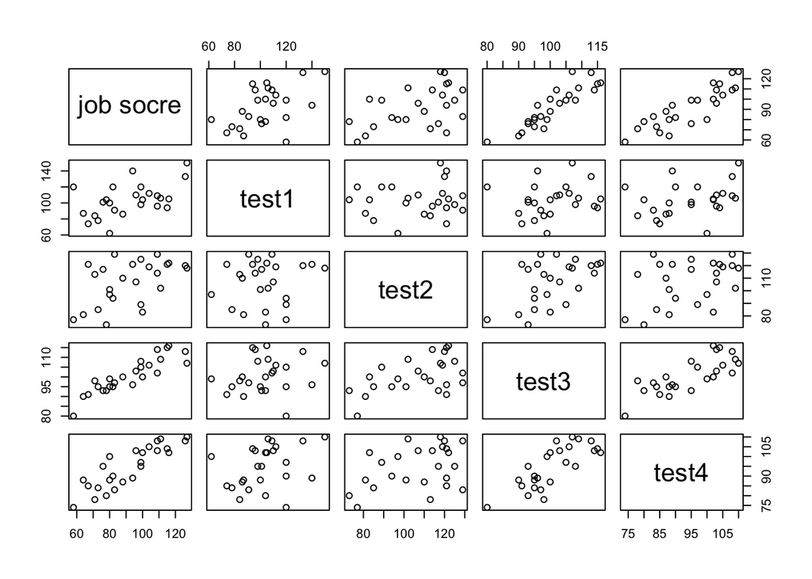

```r
pairs(data.910)
```

```r
cor(data.910)
```

```
##           job socre     test1     test2     test3     test4
## job socre 1.0000000 0.5144107 0.4970057 0.8970645 0.8693865
## test1     0.5144107 1.0000000 0.1022689 0.1807692 0.3266632
## test2     0.4970057 0.1022689 1.0000000 0.5190448 0.3967101
## test3     0.8970645 0.1807692 0.5190448 1.0000000 0.7820385
## test4     0.8693865 0.3266632 0.3967101 0.7820385 1.0000000
```

From the plot, we can find that y has linear relation with each x. And from the correlation matrix, we can also find the degree of correlationship is high among some variances. Such as correlation in x2 x3 is 0.5190448. Thus, there will be serious multicollinearity problem.

```r
x1f.910<-x1.910-mean(x1.910)
x2f.910<-x2.910-mean(x2.910)
x3f.910<-x3.910-mean(x3.910)
x4f.910<-x4.910-mean(x4.910)
fitf.910<-lm(y.910~x1f.910+x2f.910+x3f.910+x4f.910)
summary(fitf.910)
```

```
##
## Call:
## lm(formula = y.910 ~ x1f.910 + x2f.910 + x3f.910 + x4f.910)
##
## Residuals:
##     Min      1Q  Median      3Q     Max
## -5.9779 -3.4506  0.0941  2.4749  5.9959
##
## Coefficients:
##             Estimate Std. Error t value Pr(>|t|)
## (Intercept) 92.20000    0.81973 112.476  < 2e-16 ***
## x1f.910      0.29573    0.04397   6.725 1.52e-06 ***
## x2f.910      0.04829    0.05662   0.853  0.40383
## x3f.910      1.30601    0.16409   7.959 1.26e-07 ***
## x4f.910      0.51982    0.13194   3.940  0.00081 ***
## ---
## Signif. codes:  0 '***' 0.001 '**' 0.01 '*' 0.05 '.' 0.1 ' ' 1
##
## Residual standard error: 4.099 on 20 degrees of freedom
## Multiple R-squared:  0.9629, Adjusted R-squared:  0.9555
## F-statistic: 129.7 on 4 and 20 DF,  p-value: 5.262e-14
```

First order function: E{y}=92.20000+0.29573*x1+0.04829*x2+1.30601*x3+0.51982*x4

Original function: E{y}=-124.38182+0.29573*x1+0.04829*x2+1.30601*x3+0.51982*x4

From the function, x2 seems having little impact on y, but we can not make a conclusion dropping x2 or not without applying F test.